# logistic_regression_modelling_QT

Queenie

08/02/2021

```
## VIM is ready to use.
```

```
## Suggestions and bug-reports can be submitted at: https://github.com/statistikat/VIM/issues
```

## set directory to where census income dataset is located:

#load data from directory:

```r
data <- read_csv("adult.data", col_names = c("age", "workclass", "fnl_wgt", "education", "education_num", "marital_status", "occupation", "relationship", "race", "sex", "capital_gain", "capital_loss", "hours_per_week", "native_country", "income"))
```

#look at dimensions of dataset:

```r
dim(data)
```

```
## [1] 32561    15
```

```r
View(data)
```

#preview dataset:

```r
head(data,10)
```

```
## # A tibble: 10 x 15
##      age workclass fnl_wgt education education_num marital_status occupation
##    <dbl> <chr>       <dbl> <chr>             <dbl> <chr>          <chr>
##  1    39 State-gov   77516 Bachelors            13 Never-married  Adm-cleri~
##  2    50 Self-emp~   83311 Bachelors            13 Married-civ-s~ Exec-mana~
##  3    38 Private    215646 HS-grad               9 Divorced       Handlers-~
##  4    53 Private    234721 11th                  7 Married-civ-s~ Handlers-~
##  5    28 Private    338409 Bachelors            13 Married-civ-s~ Prof-spec~
##  6    37 Private    284582 Masters              14 Married-civ-s~ Exec-mana~
##  7    49 Private    160187 9th                   5 Married-spous~ Other-ser~
##  8    52 Self-emp~  209642 HS-grad               9 Married-civ-s~ Exec-mana~
##  9    31 Private     45781 Masters              14 Never-married  Prof-spec~
## 10    42 Private    159449 Bachelors            13 Married-civ-s~ Exec-mana~
## # ... with 8 more variables: relationship <chr>, race <chr>, sex <chr>,
## #   capital_gain <dbl>, capital_loss <dbl>, hours_per_week <dbl>,
## #   native_country <chr>, income <chr>
```

```r
str(data)
```

```
## tibble [32,561 x 15] (S3: spec_tbl_df/tbl_df/tbl/data.frame)
##  $ age           : num [1:32561] 39 50 38 53 28 37 49 52 31 42 ...
##  $ workclass     : chr [1:32561] "State-gov" "Self-emp-not-inc" "Private" "Private" ...
##  $ fnl_wgt       : num [1:32561] 77516 83311 215646 234721 338409 ...
##  $ education     : chr [1:32561] "Bachelors" "Bachelors" "HS-grad" "11th" ...
##  $ education_num : num [1:32561] 13 13 9 7 13 14 5 9 14 13 ...
##  $ marital_status: chr [1:32561] "Never-married" "Married-civ-spouse" "Divorced" "Married-civ-spouse" ...
##  $ occupation    : chr [1:32561] "Adm-clerical" "Exec-managerial" "Handlers-cleaners" "Handlers-cleaners" ...
##  $ relationship  : chr [1:32561] "Not-in-family" "Husband" "Not-in-family" "Husband" ...
##  $ race          : chr [1:32561] "White" "White" "White" "Black" ...
##  $ sex           : chr [1:32561] "Male" "Male" "Male" "Male" ...
##  $ capital_gain  : num [1:32561] 2174 0 0 0 0 ...
##  $ capital_loss  : num [1:32561] 0 0 0 0 0 0 0 0 0 0 ...
##  $ hours_per_week: num [1:32561] 40 13 40 40 40 40 16 45 50 40 ...
##  $ native_country: chr [1:32561] "United-States" "United-States" "United-States" "United-States" ...
##  $ income        : chr [1:32561] "<=50K" "<=50K" "<=50K" "<=50K" ...
##  - attr(*, "spec")=
##   .. cols(
##   ..   age = col_double(),
##   ..   workclass = col_character(),
##   ..   fnl_wgt = col_double(),
##   ..   education = col_character(),
##   ..   education_num = col_double(),
##   ..   marital_status = col_character(),
##   ..   occupation = col_character(),
##   ..   relationship = col_character(),
##   ..   race = col_character(),
##   ..   sex = col_character(),
##   ..   capital_gain = col_double(),
##   ..   capital_loss = col_double(),
##   ..   hours_per_week = col_double(),
##   ..   native_country = col_character(),
##   ..   income = col_character()
##   .. )
```

```r
summary(data)
```

```
##       age         workclass            fnl_wgt         education
##  Min.   :17.00   Length:32561       Min.   :  12285   Length:32561
##  1st Qu.:28.00   Class :character   1st Qu.: 117827   Class :character
##  Median :37.00   Mode  :character   Median : 178356   Mode  :character
##  Mean   :38.58                      Mean   : 189778
##  3rd Qu.:48.00                      3rd Qu.: 237051
##  Max.   :90.00                      Max.   :1484705
##  education_num   marital_status      occupation        relationship
##  Min.   : 1.00   Length:32561       Length:32561       Length:32561
##  1st Qu.: 9.00   Class :character   Class :character   Class :character
##  Median :10.00   Mode  :character   Mode  :character   Mode  :character
##  Mean   :10.08
##  3rd Qu.:12.00
##  Max.   :16.00
##      race               sex             capital_gain    capital_loss
##  Length:32561       Length:32561       Min.   :    0   Min.   :   0.0
##  Class :character   Class :character   1st Qu.:    0   1st Qu.:   0.0
##  Mode  :character   Mode  :character   Median :    0   Median :   0.0
##                                        Mean   : 1078   Mean   :  87.3
##                                        3rd Qu.:    0   3rd Qu.:   0.0
##                                        Max.   :99999   Max.   :4356.0
##  hours_per_week  native_country        income
##  Min.   : 1.00   Length:32561       Length:32561
##  1st Qu.:40.00   Class :character   Class :character
##  Median :40.00   Mode  :character   Mode  :character
##  Mean   :40.44
##  3rd Qu.:45.00
##  Max.   :99.00
```

#check distribution of target variable which is class:

```r
table(data$income)
```

```
##
## <=50K  >50K
## 24720  7841
```

#look at target variable income:

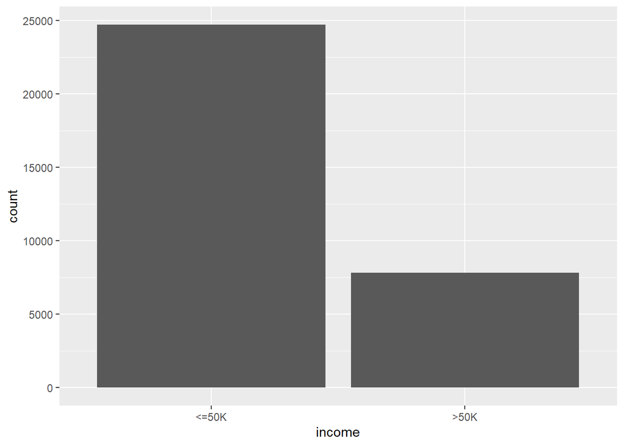

```r
ggplot(data = data) +
  geom_bar(mapping = aes(x = income))
```

#testing for missing values:

```r
sapply(data, function(x) sum(is.na (x)))
```

```
##            age      workclass        fnl_wgt      education  education_num
##              0              0              0              0              0
## marital_status     occupation   relationship           race            sex
##              0              0              0              0              0
##   capital_gain   capital_loss hours_per_week native_country         income
##              0              0              0              0              0
```

#from the Feature Engineering.R class example file to get the numeric columns only:

```r
list_of_numcols = sapply(data, is.numeric)
numcols = data[ , list_of_numcols]
```

#histograms for numeric variables:

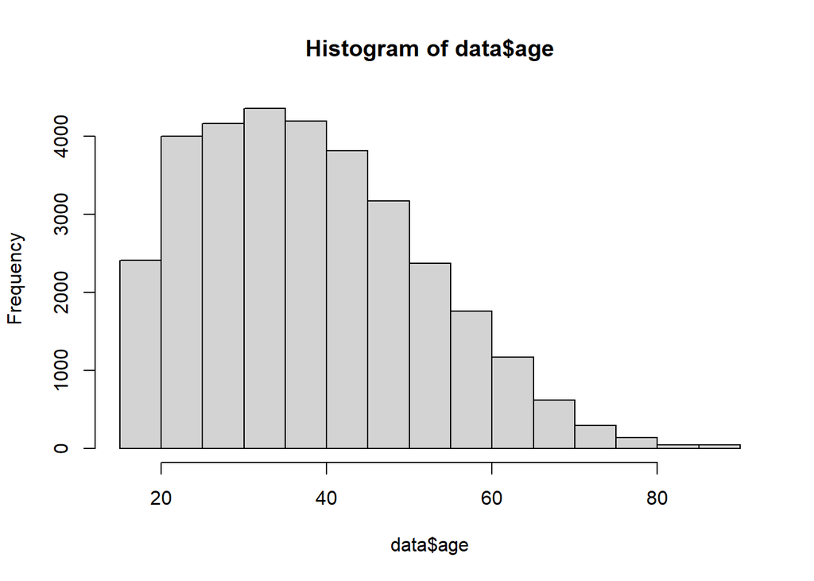

```r
hist(data$age)
```

#age vs income

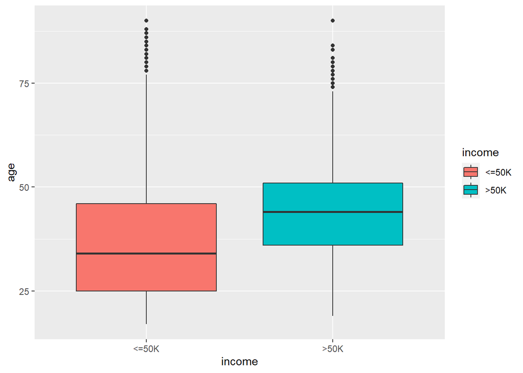

```r
ggplot(data = data, aes(x=income, y = age)) +
  geom_boxplot(aes(fill=income))
```

#fnlwght vs income

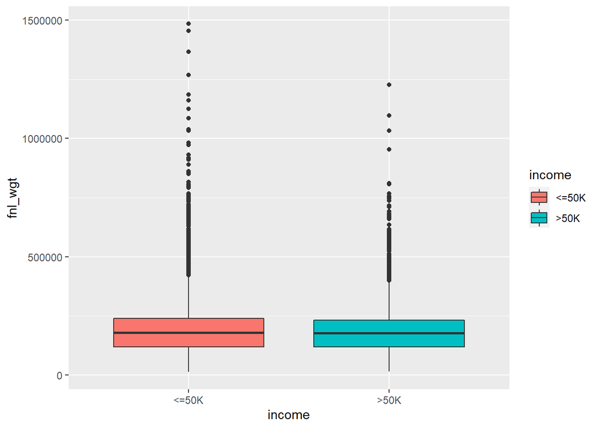

```r
ggplot(data = data, aes(x=income, y = fnl_wgt)) +
  geom_boxplot(aes(fill=income))
```

#education_num vs income

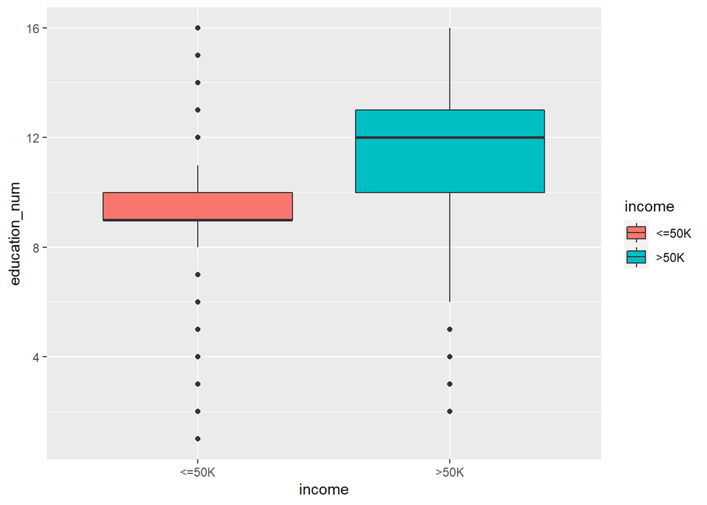

```r
ggplot(data = data, aes(x=income, y = education_num)) +
  geom_boxplot(aes(fill=income))
```

#capital_gain vs income

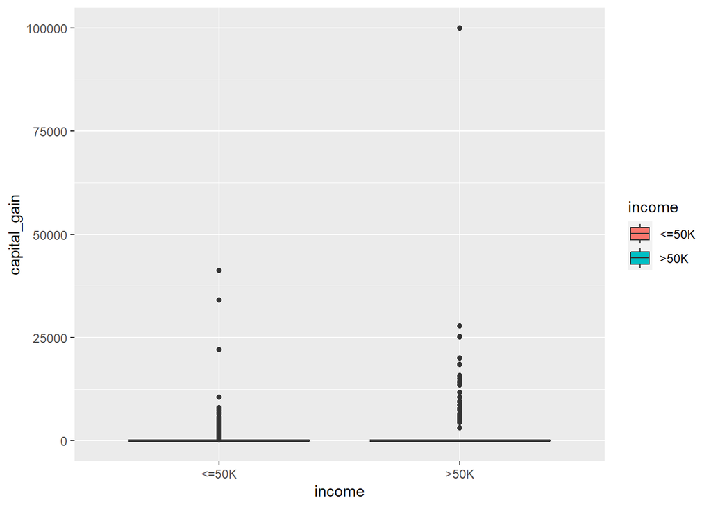

```r
ggplot(data = data, aes(x=income, y = capital_gain)) +
  geom_boxplot(aes(fill=income))
```

#capital_loss vs income

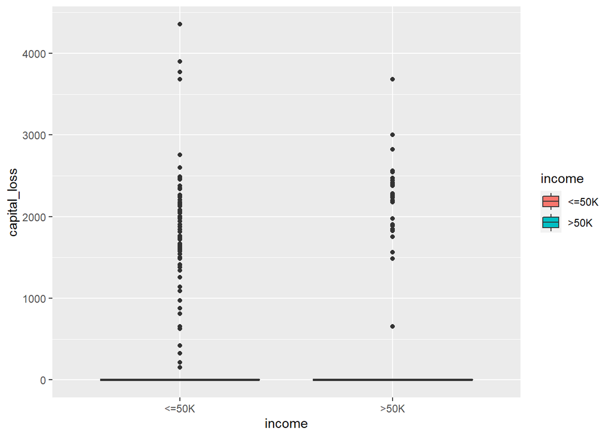

```r
ggplot(data = data, aes(x=income, y = capital_loss)) +
  geom_boxplot(aes(fill=income))
```

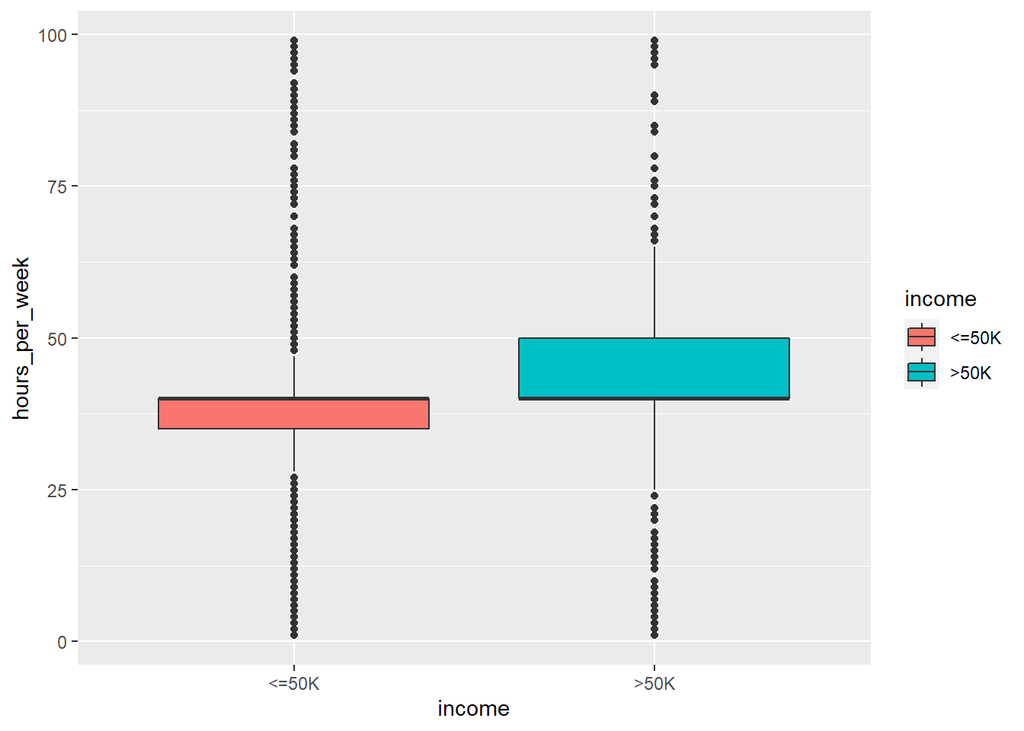

```r
#hours per week vs income
ggplot(data = data, aes(x=income, y = hours_per_week)) +
  geom_boxplot(aes(fill=income))
```

```r
##################looking at categorical variables:#########
attach(data)
freq_tbl=table(sex)
head(freq_tbl)
```

```
## sex
## Female   Male
##  10771  21790
```

```r
#to get proportion, input frequency table:
prop.table(freq_tbl)
```

```
## sex
##    Female      Male
## 0.3307945 0.6692055
```

```r
#looking at education:
freq_tbl_education= table(education)
head(freq_tbl_education)
```

```
## education
##    10th    11th    12th 1st-4th 5th-6th 7th-8th
##     933    1175     433     168     333     646
```

```r
prop.table(freq_tbl_education)
```

```
## education
##         10th         11th         12th      1st-4th      5th-6th      7th-8th
##  0.028653911  0.036086115  0.013298117  0.005159547  0.010226959  0.019839686
##          9th   Assoc-acdm    Assoc-voc    Bachelors    Doctorate      HS-grad
##  0.015785756  0.032769264  0.042443414  0.164460551  0.012683886  0.322502380
##      Masters    Preschool  Prof-school Some-college
##  0.052916065  0.001566291  0.017689874  0.223918184
```

```r
#look at target variable income with respect to education:
freq_xtab=xtabs(~education+income)
head(freq_xtab)
```

```
##          income
## education <=50K >50K
##   10th      871   62
##   11th     1115   60
##   12th      400   33
##   1st-4th   162    6
##   5th-6th   317   16
##   7th-8th   606   40
```

```r
#cross-tab for 2 categorical features, this time with proportions:
prop.table(freq_xtab)
```

```
##               income
## education             <=50K         >50K
##   10th         0.0267497927 0.0019041184
##   11th         0.0342434200 0.0018426952
##   12th         0.0122846350 0.0010134824
##   1st-4th      0.0049752772 0.0001842695
##   5th-6th      0.0097355732 0.0004913854
##   7th-8th      0.0186112220 0.0012284635
##   9th          0.0149565431 0.0008292129
##   Assoc-acdm   0.0246306932 0.0081385707
##   Assoc-voc    0.0313565308 0.0110868831
##   Bachelors    0.0962501152 0.0682104358
##   Doctorate    0.0032861399 0.0093977458
##   HS-grad      0.2710604711 0.0514419090
##   Masters      0.0234636528 0.0294524124
##   Preschool    0.0015662910 0.0000000000
##   Prof-school  0.0046988729 0.0129910015
##   Some-college 0.1813212125 0.0425969718
```

```r
#use DPLYR to see the relationship between education and education-num:
income_by_education =
  data %>%
  group_by(education) %>%
  summarise(education_num = mean(education_num, na.rm = TRUE))
```

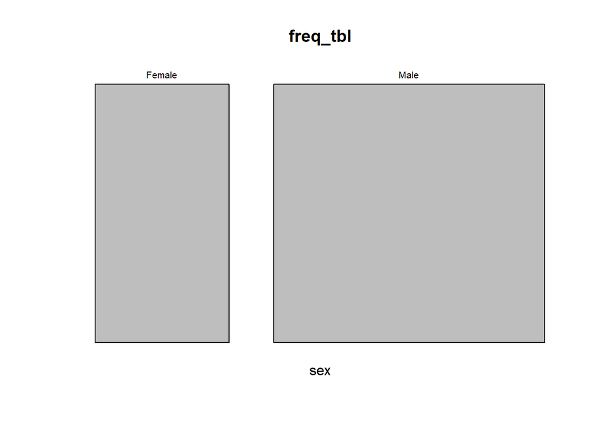

```r
#creating a mosaic plot (plot of proportions)
mosaicplot(freq_tbl)
```

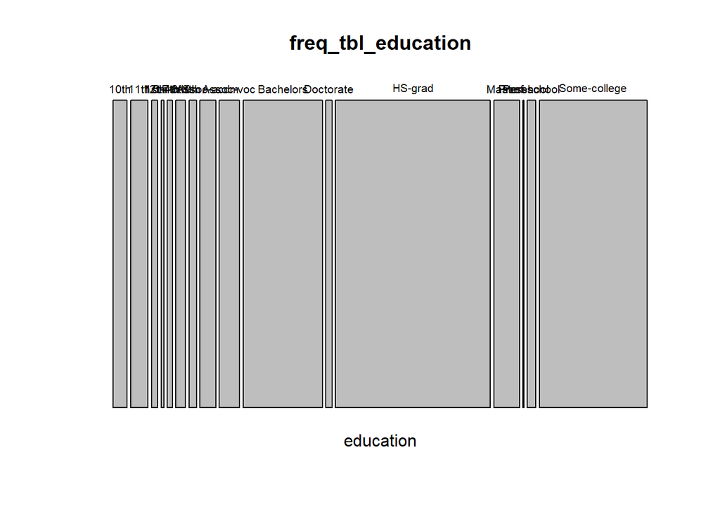

```r
mosaicplot(freq_tbl_education)
```

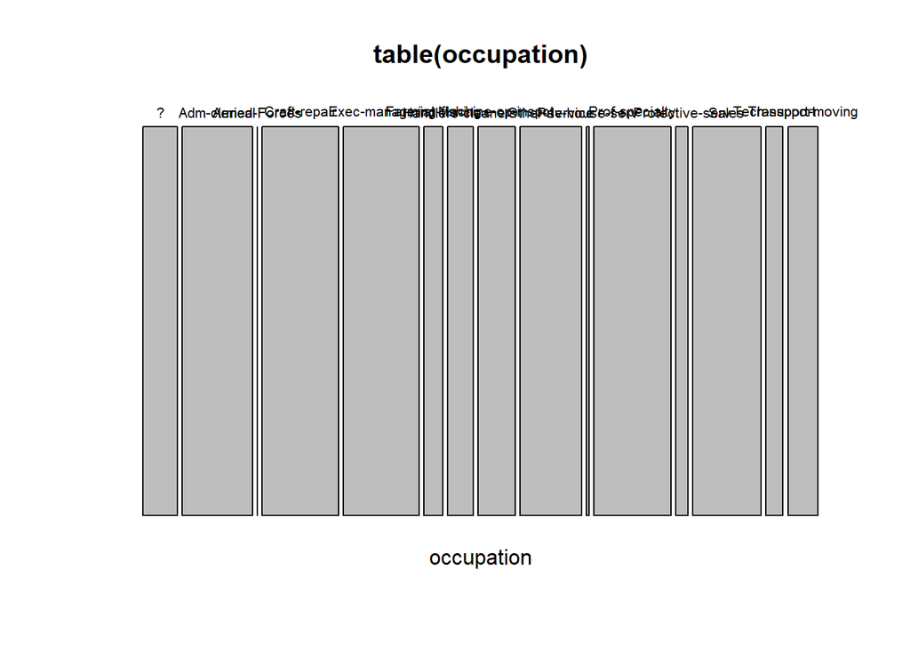

```r
########looking at categorical variables#################:
mosaicplot(table(occupation))
```

```r
#Stacked bar-plot - i.e. plotting it x-tab
freq_xtab=xtabs(~occupation+income)
head(freq_xtab)
```

```
##                  income
## occupation        <=50K >50K
##   ?                1652  191
##   Adm-clerical     3263  507
##   Armed-Forces        8    1
##   Craft-repair     3170  929
##   Exec-managerial  2098 1968
##   Farming-fishing   879  115
```

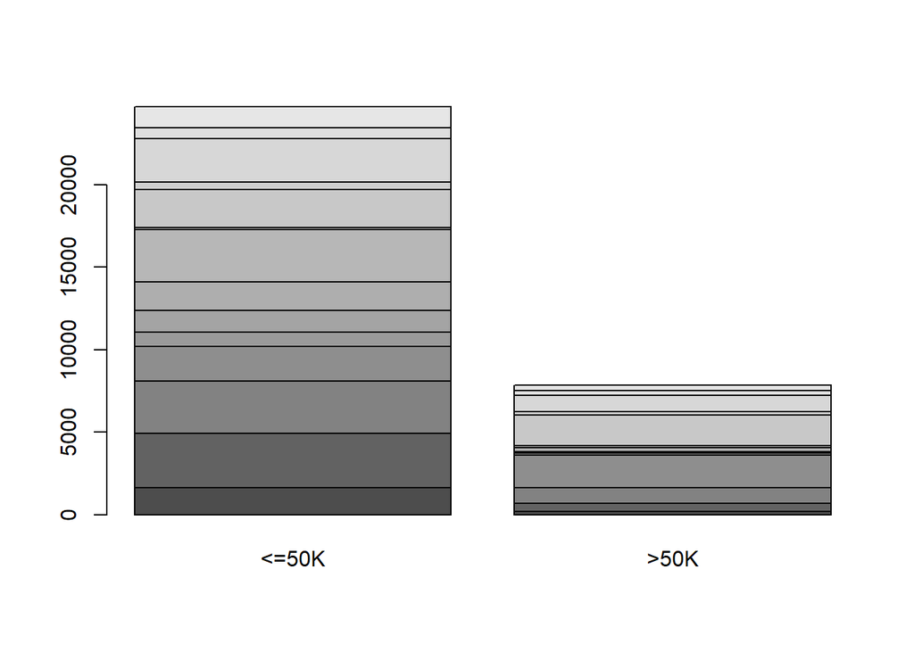

```r
#basic bar-plot will automatically be stacked if we give it the x-tab table as an input
#barplot of occupation vs income:
barplot(freq_xtab)
```

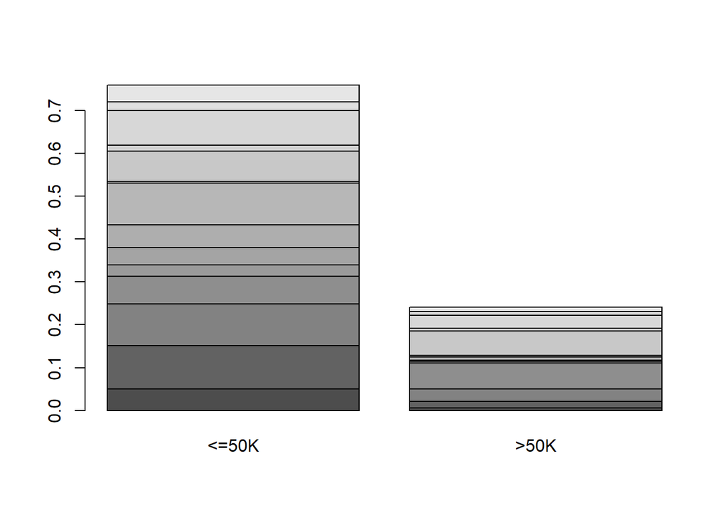

```r
barplot(prop.table(freq_xtab))
```

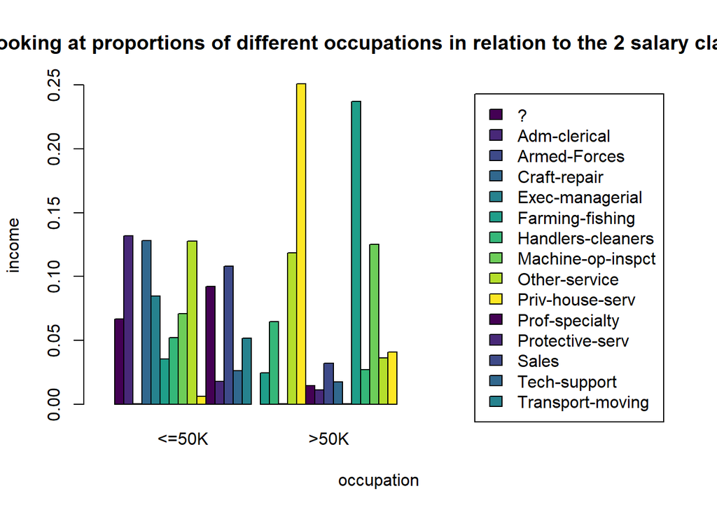

```r
barplot(prop.table(freq_xtab,2),
        legend=rownames(freq_xtab),  beside = TRUE,
        ylab = "income", xlab = "occupation",
        main = "looking at proportions of different occupations in relation to the 2 salary classes",
        xlim = c(0,60),
        col = viridis(10))
```

```r
#look at workclass versus income (2 categorical variables)
workclass_vs_income_freq_xtab=xtabs(~workclass+income)
head(workclass_vs_income_freq_xtab)
```

```
##               income
## workclass      <=50K  >50K
##   ?             1645   191
##   Federal-gov    589   371
##   Local-gov     1476   617
##   Never-worked     7     0
##   Private      17733  4963
##   Self-emp-inc   494   622
```

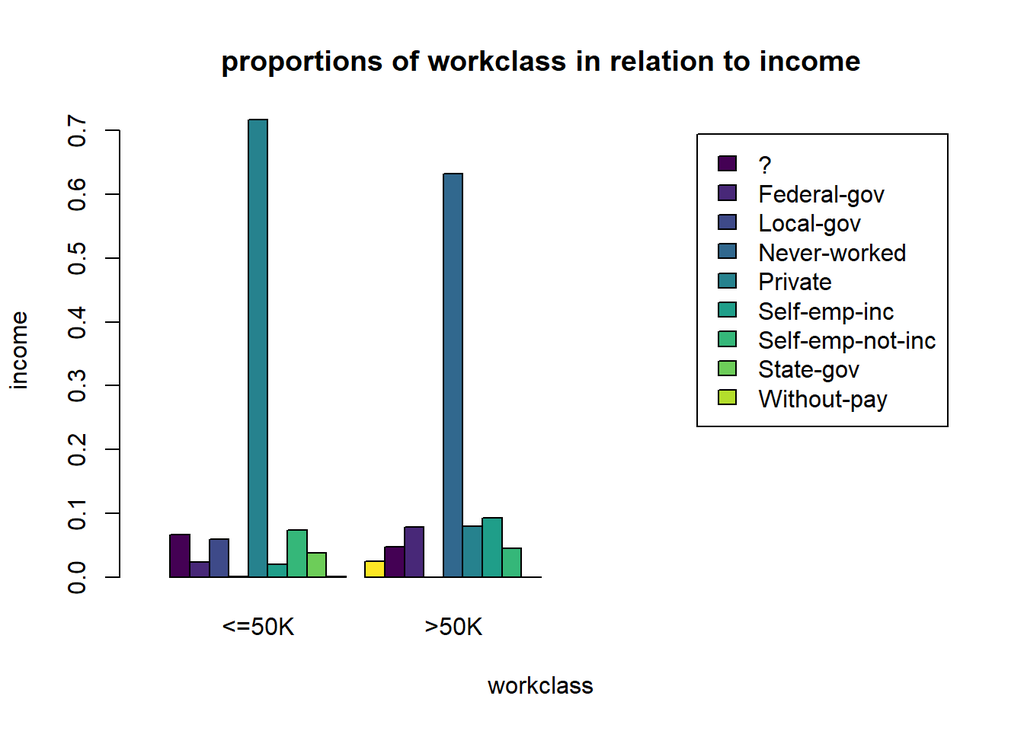

```r
workclass_vs_income_freq_xtab = table(workclass, income) #create a simple frequency table of workclass vs class
workclass_vs_income_pct_xtab = prop.table(workclass_vs_income_freq_xtab, 2)  #turn into a proportion table
barplot(workclass_vs_income_pct_xtab,
        legend=rownames(workclass_vs_income_pct_xtab), beside = TRUE,
        ylab = "income", xlab = "workclass",
        main = "proportions of workclass in relation to income",
        xlim = c(0, 40),
        col = viridis(10))
```

```r
#plotting marital status vs income:
marital_status_vs_income_freq_xtab=xtabs(~marital_status+income)
head(marital_status_vs_income_freq_xtab)
```

```
##                        income
## marital_status          <=50K  >50K
##   Divorced               3980   463
##   Married-AF-spouse        13    10
##   Married-civ-spouse     8284  6692
##   Married-spouse-absent   384    34
##   Never-married         10192   491
##   Separated               959    66
```

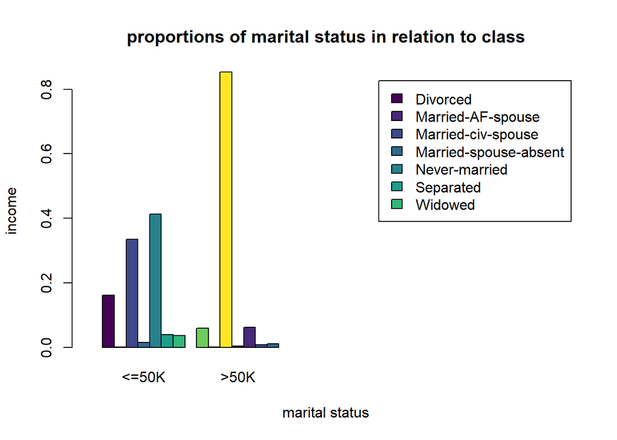

```r
marital_status_vs_income_freq_xtab = table(marital_status,income)
marital_status_vs_income_pct_xtab = prop.table(marital_status_vs_income_freq_xtab,2)
barplot(marital_status_vs_income_pct_xtab,
        legend= rownames(marital_status_vs_income_pct_xtab), beside = TRUE,
        ylab = "income", xlab = "marital status",
        main = "proportions of marital status in relation to class",
        xlim = c(0, 40),   #this is used to move legend to the right
        col = viridis(10))
```

```r
#not sure why yellow colour in one of the columns but not in the legend??
```

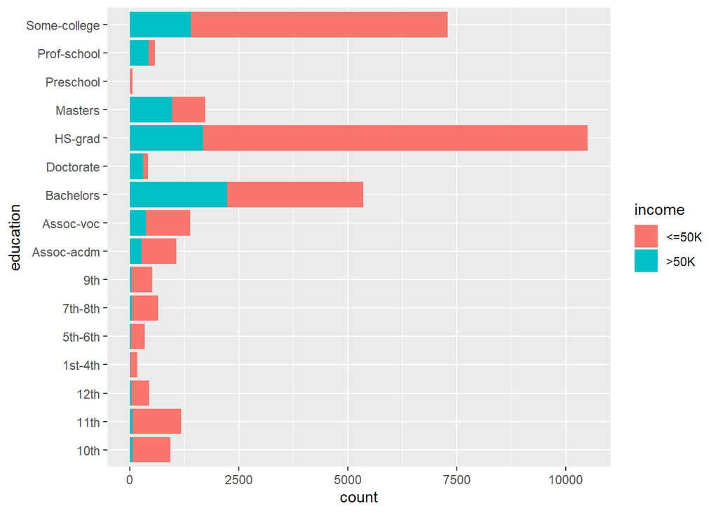

```r
#plotting education vs income
ggplot(data = data, aes(y = education, fill = income)) +
  geom_bar(position = "stack")   #different bars stacked together
```

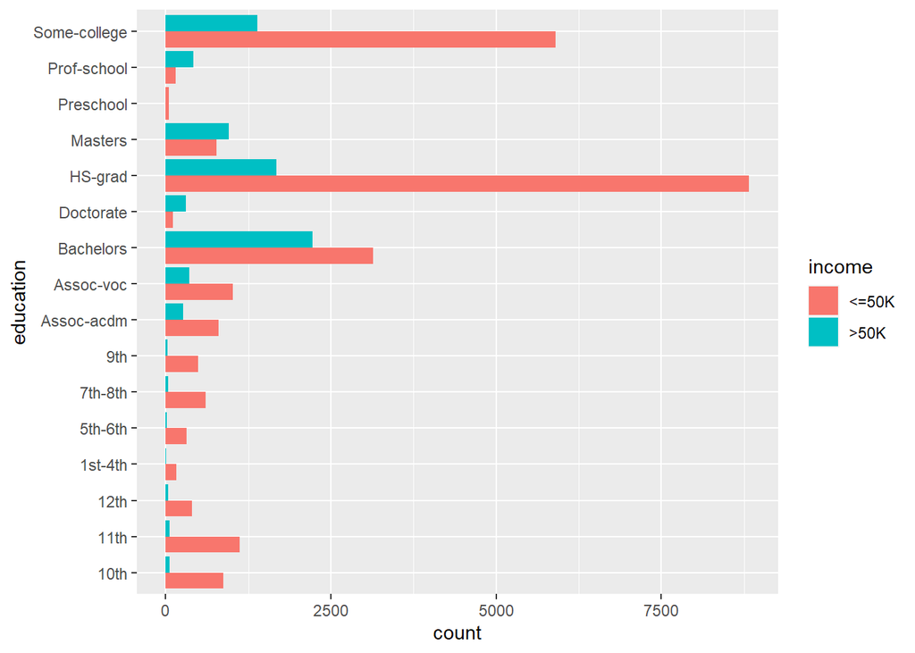

```r
ggplot(data = data, aes(y = education, fill = income)) +
  geom_bar(position = "dodge")   #different bars side by side
```

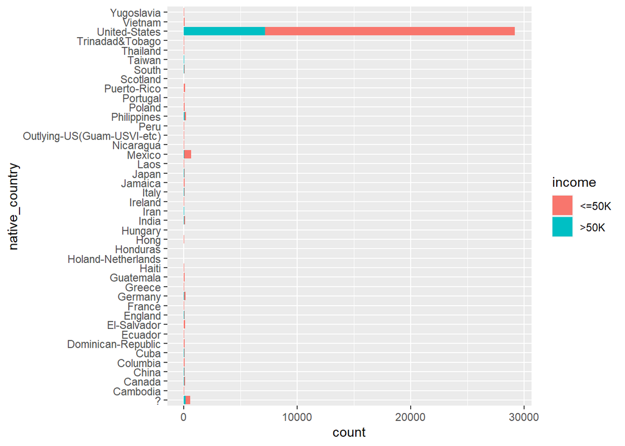

```r
#plotting native country vs. income
ggplot(data = data, aes(y = native_country, fill = income))+
  geom_bar(position = "stack")
```

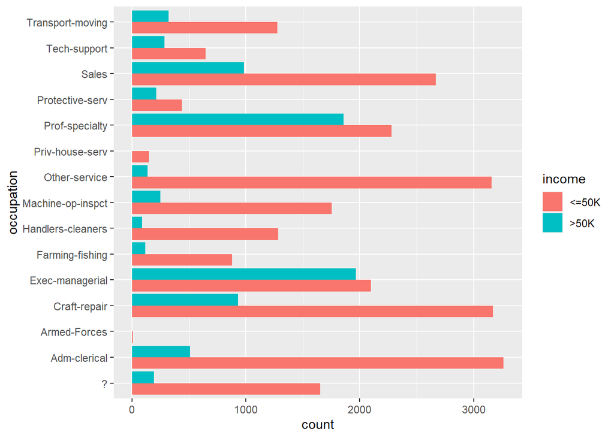

```r
#plotting occupation vs income
ggplot(data = data, aes(y = occupation, fill = income))+
  geom_bar(position = "dodge")
```

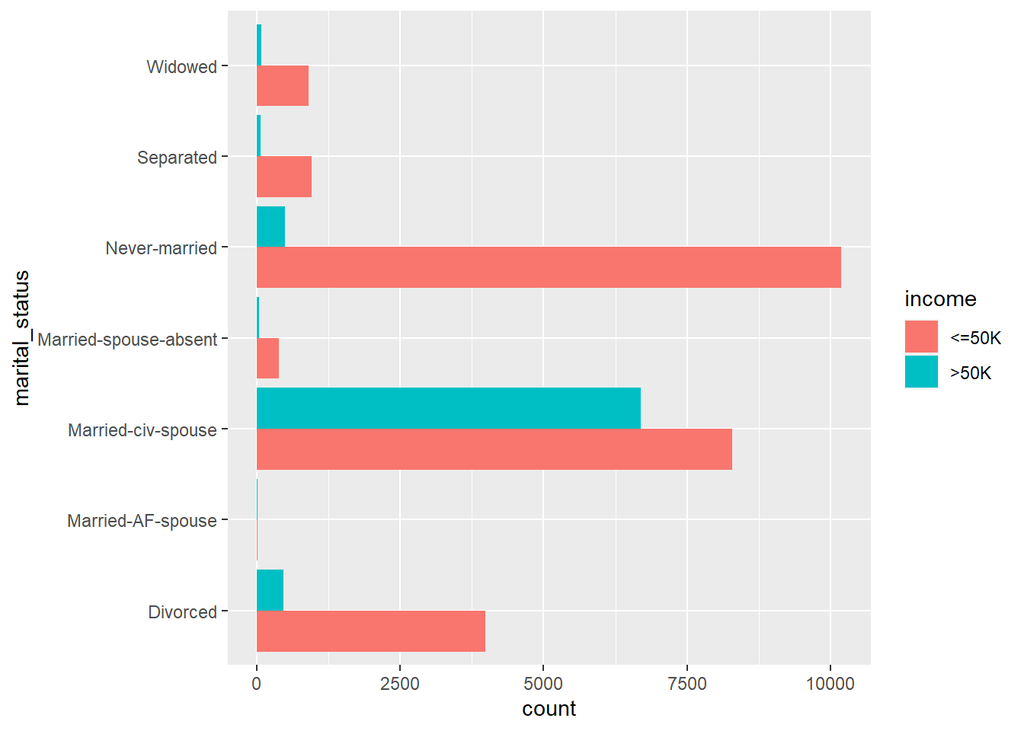

```r
#plotting marital status vs. income
ggplot(data = data, aes(y = marital_status, fill = income))+
  geom_bar(position = "dodge")
```

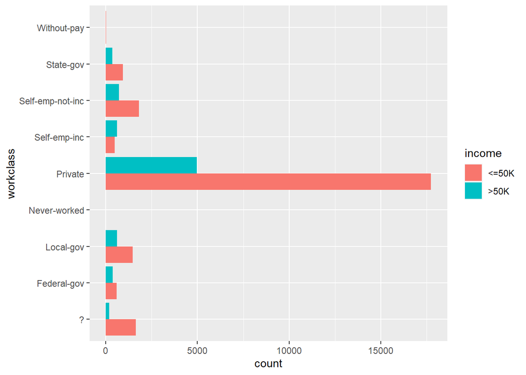

```r
#plot workclass vs. income
ggplot(data = data, aes(y = workclass, fill = income))+
  geom_bar(position = "dodge")
```

```r
#missing values are represented by "?" in the dataset

#convert ? values to NA in dataset and save into new dataframe:
data_NA <- as.data.frame(data %>%
                           mutate_if(is.character, list(~na_if(., "?"))))
```

####missing values ##########

#####getting the percentage of missing values:

```r
percent_missing = function(x){sum(is.na(x))/length(x)*100}
apply(data_NA,2,percent_missing)
```

```
##            age      workclass        fnl_wgt      education  education_num
##       0.000000       5.638647       0.000000       0.000000       0.000000
## marital_status     occupation   relationship           race            sex
##       0.000000       5.660146       0.000000       0.000000       0.000000
##   capital_gain   capital_loss hours_per_week native_country         income
##       0.000000       0.000000       0.000000       1.790486       0.000000
```

```r
#look at distinct native countries and the counts for each:
data_NA %>% count(native_country)
```

```
##                native_country     n
## 1                    Cambodia    19
## 2                      Canada   121
## 3                       China    75
## 4                    Columbia    59
## 5                        Cuba    95
## 6          Dominican-Republic    70
## 7                     Ecuador    28
## 8                 El-Salvador   106
## 9                     England    90
## 10                     France    29
## 11                    Germany   137
## 12                     Greece    29
## 13                  Guatemala    64
## 14                      Haiti    44
```

[output cut: 28 more lines]

```r
#replace "Hong" to "Hong Kong" in native_country column for clarity:
data_NA$native_country <-  str_replace(as.character(data_NA$native_country), "Hong", "Hong Kong")
```

```r
#total missing NA values:
sum(is.na(data_NA))
```

```
## [1] 4262
```

```r
#compute the total missing values in each column:
colSums(is.na(data_NA))
```

```
##            age      workclass        fnl_wgt      education  education_num
##              0           1836              0              0              0
## marital_status     occupation   relationship           race            sex
##              0           1843              0              0              0
##   capital_gain   capital_loss hours_per_week native_country         income
##              0              0              0            583              0
```

```r
####missing values ##########

#####getting the percentage of missing values:

percent_missing = function(x){sum(is.na(x))/length(x)*100}
apply(data_NA,2,percent_missing)
```

```
##            age      workclass        fnl_wgt      education  education_num
##       0.000000       5.638647       0.000000       0.000000       0.000000
## marital_status     occupation   relationship           race            sex
##       0.000000       5.660146       0.000000       0.000000       0.000000
##   capital_gain   capital_loss hours_per_week native_country         income
##       0.000000       0.000000       0.000000       1.790486       0.000000
```

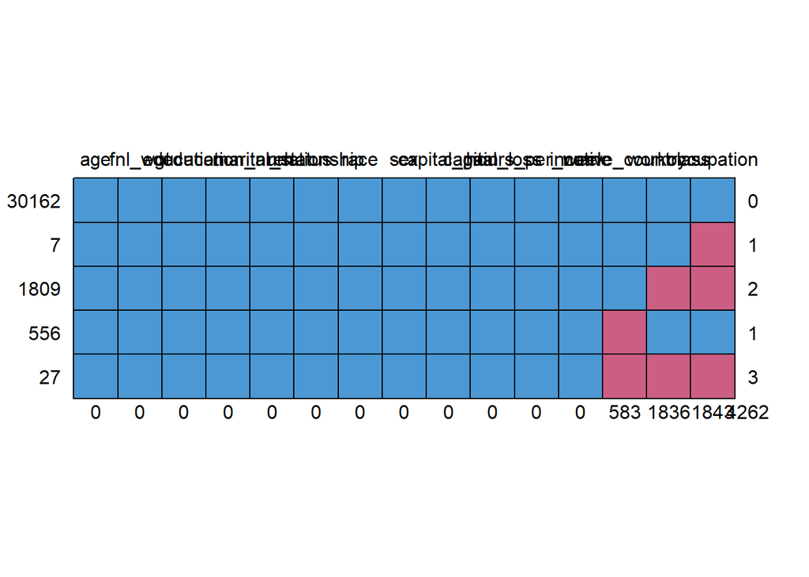

```
##       age fnl_wgt education education_num marital_status relationship race sex
## 30162   1       1         1             1              1            1    1   1
## 7       1       1         1             1              1            1    1   1
## 1809    1       1         1             1              1            1    1   1
## 556     1       1         1             1              1            1    1   1
## 27      1       1         1             1              1            1    1   1
##         0       0         0             0              0            0    0   0
##       capital_gain capital_loss hours_per_week income native_country workclass
## 30162            1            1              1      1              1         1
## 7                1            1              1      1              1         1
## 1809             1            1              1      1              1         0
## 556              1            1              1      1              0         1
## 27               1            1              1      1              0         0
##                  0            0              0      0            583      1836
##       occupation
## 30162          1    0
## 7              0    1
## 1809           0    2
## 556            1    1
## 27             0    3
##             1843 4262
```

```r
#visualizing missing values:
##install.packages("mice")
library(mice)

md.pattern(data_NA)
```

###1’s represents variable presence #### 0’s under each variable represent their missing state

###there are 7 rows where occupation is missing. ###there are 1809 rows where workclass and occupation are missing. ###there are 27 rows where native country, workclass and occupation are missing.

```r
##look at whether there is duplicate data:

duplicated(data_NA)
```

[output not shown]

[output cut: 2699 more lines]

```r
#to get the original number of rows in dataset:
nrow(data_NA)
```

```
## [1] 32561
```

```r
#apply unique() on a data frame, for removing duplicated rows:
data_unique <- unique(data_NA)
nrow(data_unique)
```

```
## [1] 32537
```

###the difference between the number of rows of original data and the unique dataset is 24, meaning ###there were 24 duplicate rows of data which have now been removed.

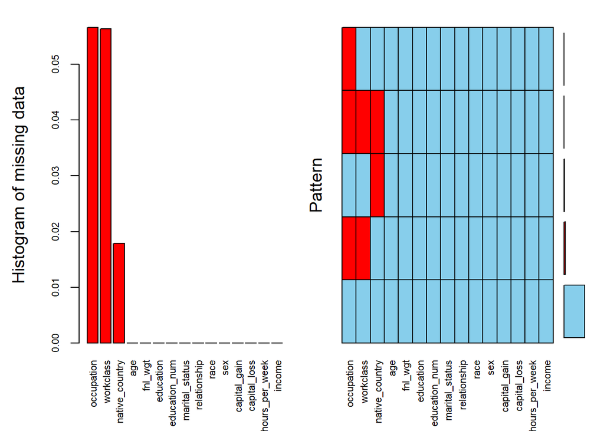

```
##
##  Variables sorted by number of missings:
##        Variable      Count
##      occupation 0.05664321
##       workclass 0.05642807
##  native_country 0.01788733
##             age 0.00000000
##         fnl_wgt 0.00000000
##       education 0.00000000
##   education_num 0.00000000
##  marital_status 0.00000000
##    relationship 0.00000000
##            race 0.00000000
##             sex 0.00000000
##    capital_gain 0.00000000
##    capital_loss 0.00000000
##  hours_per_week 0.00000000
##          income 0.00000000
```

```r
#visualize the missing data:
library(VIM)
#The function VIM aggr calculates and represents the number of missing entries in each
#variable and for certain combinations of variables (which tend to be missing simultaneously)
aggr_plot = aggr(data_unique, col=c('skyblue','red', 'orange'), numbers=TRUE, sortVars=TRUE, labels=names(data_unique), cex.axis=.7, gap=3, ylab=c("Histogram of missing data","Pattern"))
```

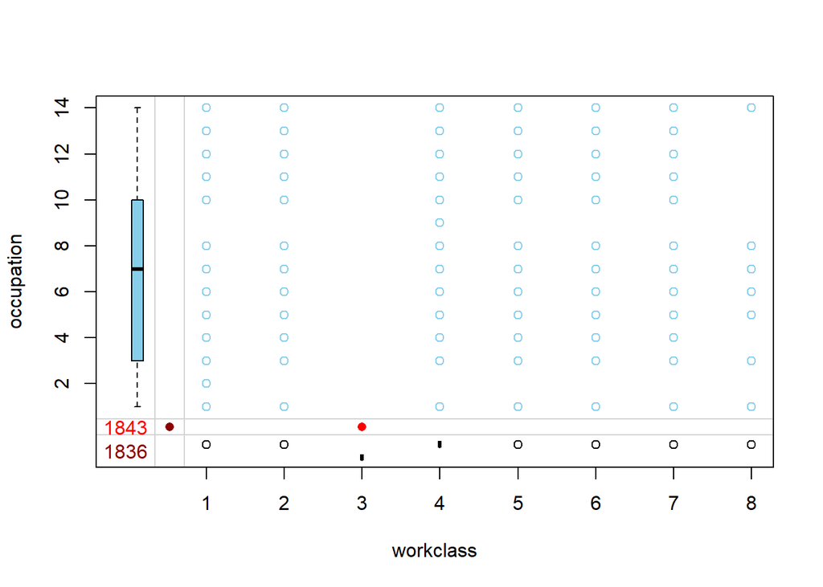

```r
#missing values margin plot:
#Drawing margin plot

#http://juliejosse.com/wp-content/uploads/2018/06/DataAnalysisMissingR.html:
# The VIM function marginplot creates a scatterplot with additional information on the missing values.
# If you plot the variables (x,y), the points with no missing values are represented as in a standard
# scatterplot. The points for which x (resp. y) is missing are represented in red along the y (resp. x)
# axis. In addition, boxplots of the x and y variables are represented along the axes with and without
# missing values (in red all variables x where y is missing, in blue all variables x where y is observed).
marginplot(data_unique[, c("workclass", "occupation")])
```

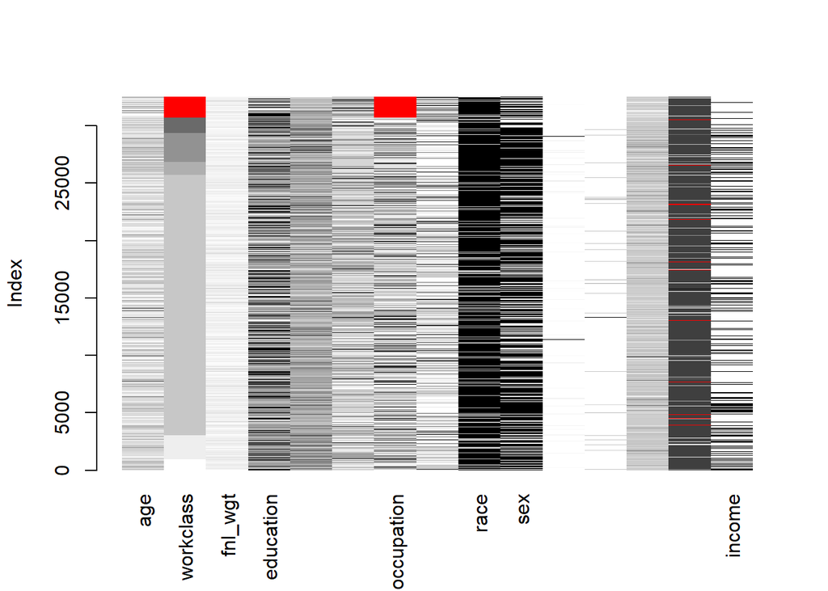

```r
#from http://juliejosse.com/wp-content/uploads/2018/06/DataAnalysisMissingR.html:
#The VIM function matrixplot creates a matrix plot in which all cells of a data matrix are
#visualized by rectangles. Available data is coded according to a continuous color scheme
#(gray scale), while missing/imputed data is visualized by a clearly distinguishable color (red).
#If you use Rstudio the plot is not interactive (there are the warnings), but if you use R directly,
#you can click on a column of your choice: the rows are sorted (decreasing order) of the values of this column.
#This is useful to check if there is an association between the value of a variable and the missingness of another one
matrixplot(data_unique, sortby = 2)
```

```r
##look at the proportional distribution of occupation feature:
data_unique %>%
  select(occupation, income) %>%
  table() %>%
  prop.table()
```

```
##                    income
## occupation                 <=50K         >50K
##   Adm-clerical      1.062423e-01 1.651789e-02
##   Armed-Forces      2.606373e-04 3.257966e-05
##   Craft-repair      1.031146e-01 3.026650e-02
##   Exec-managerial   6.831954e-02 6.411677e-02
##   Farming-fishing   2.857236e-02 3.746661e-03
##   Handlers-cleaners 4.179970e-02 2.801851e-03
##   Machine-op-inspct 5.704698e-02 8.112335e-03
##   Other-service     1.027562e-01 4.463413e-03
##   Priv-house-serv   4.756630e-03 3.257966e-05
##   Prof-specialty    7.421646e-02 6.053300e-02
##   Protective-serv   1.426989e-02 6.874308e-03
##   Sales             8.688995e-02 3.202580e-02
##   Tech-support      2.098130e-02 9.220043e-03
##   Transport-moving  4.160422e-02 1.042549e-02
```

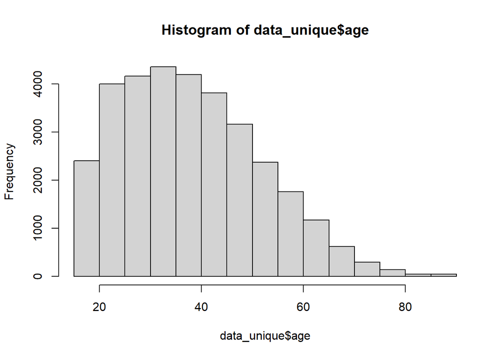

```r
#########Numeric variables ########
hist(data_unique$age)
```

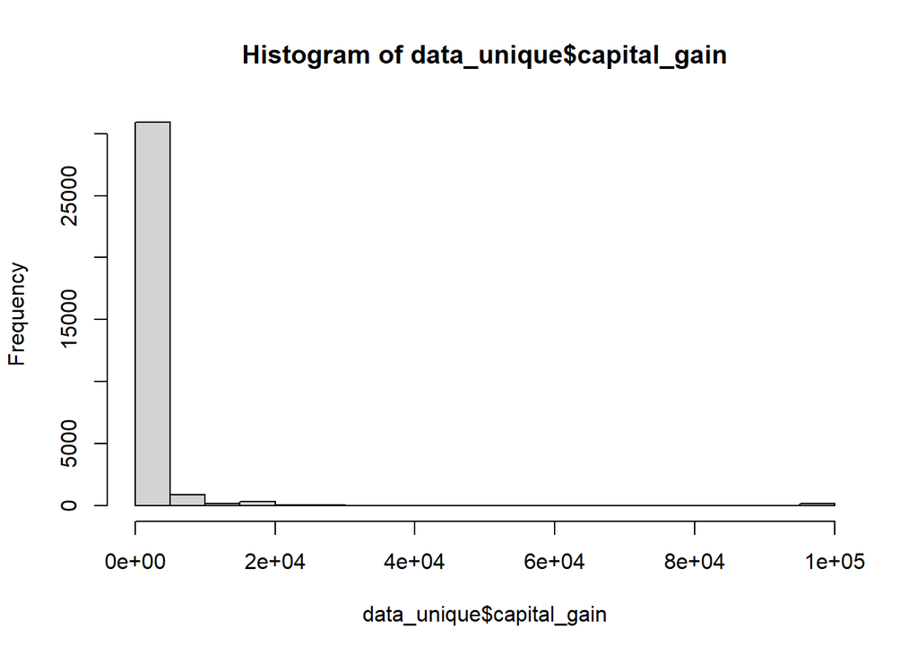

```r
hist(data_unique$capital_gain)
```

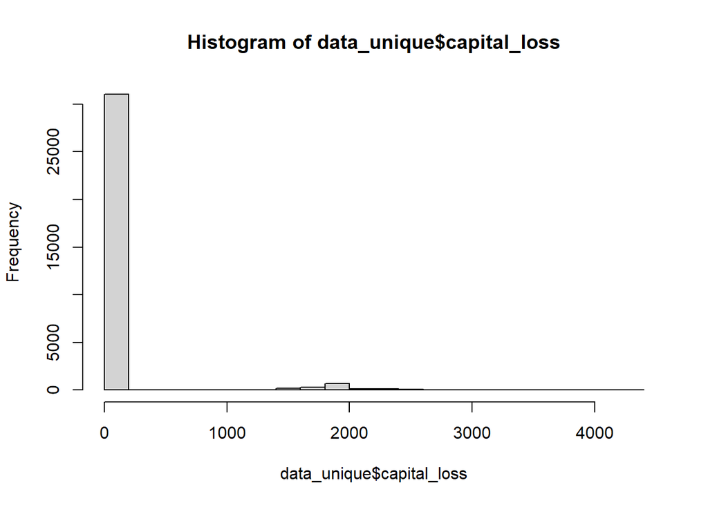

```r
hist(data_unique$capital_loss)
```

```r
#making histograms for all numeric variables:
list_of_numcols = sapply(data_unique, is.numeric)
numcols = data_unique[ , list_of_numcols]
```

```r
#Step 2: Melt data --> Turn it into skinny LONG table
melt_data = melt(numcols)
head(melt_data, 10)
```

```
##    variable value
## 1       age    39
## 2       age    50
## 3       age    38
## 4       age    53
## 5       age    28
## 6       age    37
## 7       age    49
## 8       age    52
## 9       age    31
## 10      age    42
```

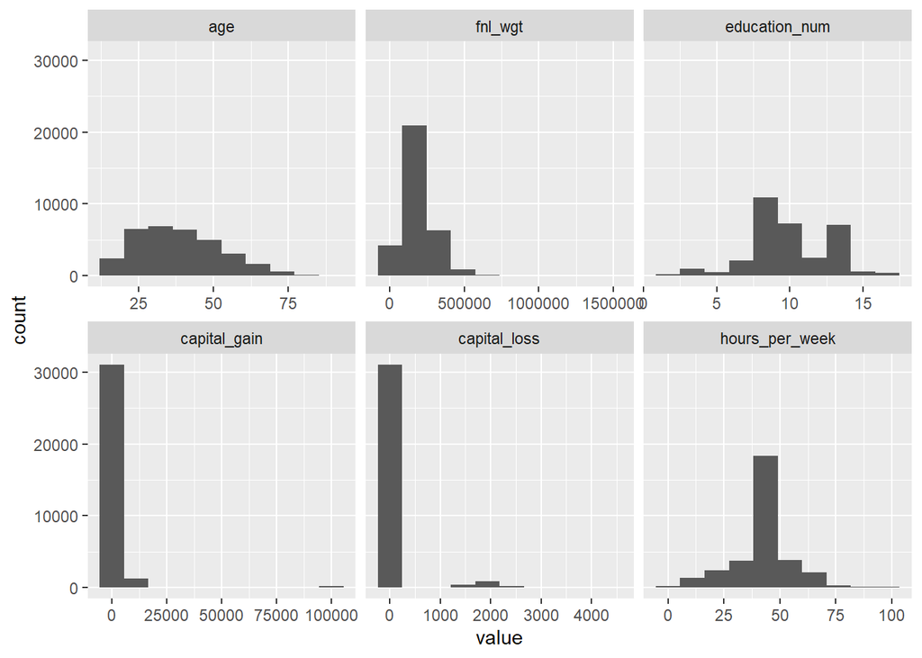

```r
#multiplot histograms of numeric variables:
ggplot(data = melt_data, mapping = aes(x = value)) + geom_histogram(bins = 10) + facet_wrap(~variable, scales = 'free_x')
```

```r
#visualizing numeric variables in relation to the target variable income:
library(Hmisc)    #used for binning numeric variable:
```

```r
#create a factor to bin the ages:
binned_age = cut2(data_unique$age, g=10, minmax=TRUE, oneval=TRUE)
data_age_binned = cbind(data_unique, binned_age)
head(data_age_binned)
```

```
##   age        workclass fnl_wgt education education_num     marital_status
## 1  39        State-gov   77516 Bachelors            13      Never-married
## 2  50 Self-emp-not-inc   83311 Bachelors            13 Married-civ-spouse
## 3  38          Private  215646   HS-grad             9           Divorced
## 4  53          Private  234721      11th             7 Married-civ-spouse
## 5  28          Private  338409 Bachelors            13 Married-civ-spouse
## 6  37          Private  284582   Masters            14 Married-civ-spouse
##          occupation  relationship  race    sex capital_gain capital_loss
## 1      Adm-clerical Not-in-family White   Male         2174            0
## 2   Exec-managerial       Husband White   Male            0            0
## 3 Handlers-cleaners Not-in-family White   Male            0            0
## 4 Handlers-cleaners       Husband Black   Male            0            0
## 5    Prof-specialty          Wife Black Female            0            0
## 6   Exec-managerial          Wife White Female            0            0
##   hours_per_week native_country income binned_age
## 1             40  United-States  <=50K    [38,42)
## 2             13  United-States  <=50K    [46,51)
## 3             40  United-States  <=50K    [38,42)
## 4             40  United-States  <=50K    [51,59)
## 5             40           Cuba  <=50K    [27,31)
## 6             40  United-States  <=50K    [34,38)
```

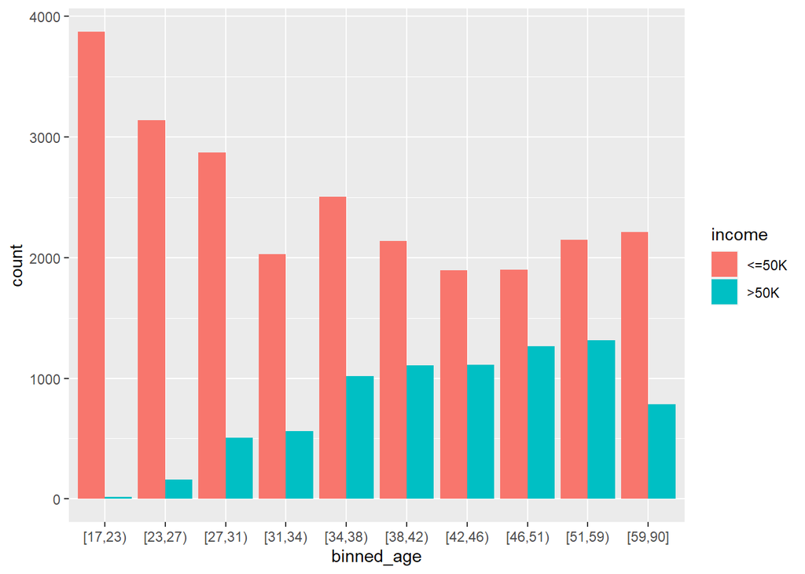

```r
#visualize age vs. income class:
ggplot(data_age_binned, aes(binned_age, ..count..)) + geom_bar(aes(fill = income), position = "dodge")
```

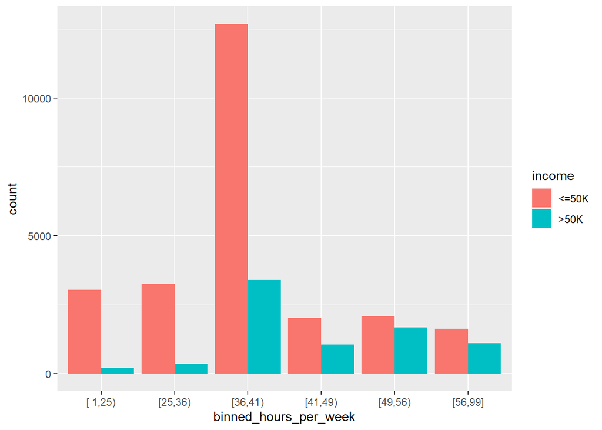

```r
#visualize hours per week vs income class:
binned_hours_per_week = cut2(data_unique$hours_per_week, g=10, minmax=TRUE, oneval=TRUE)
data_age_hours = cbind(data_age_binned, binned_hours_per_week)    #combine the new factor for binned hours with the binned_age dataframe
ggplot(data_age_hours, aes(binned_hours_per_week, ..count..)) + geom_bar(aes(fill = income), position = "dodge")
```